# Agriculture Sector Analysis using CRISP-DM Framework

Wong Yi Ting (S2152880)

2025-01-02

# **The Role of Data Science in Agriculture Sector**

## **Introduction**

Data science enables better understanding and management of agricultural price volatility by analyzing trends, predicting fluctuations, and providing actionable insights. This study specifically focuses on leveraging predictive models to assist policymakers and farmers in making informed decisions to optimize production strategies and mitigate risks.

## **CRISP-DM Framework Analysis**

### **1. Business Understanding**

Volatile agricultural prices directly impact farmers’ income and decision-making processes. This study aims to:  
**1.** Predict future agriculture PPI values using time series models.  
**2.** Use other industries’ PPI data to predict agriculture PPI using regression models.

These objectives address critical industry needs, such as stabilizing market conditions and improving income predictability for stakeholders.

### **2. Data Understanding**

- **Dataset Source**: Department of Statistics Malaysia
- **Fields**:
  - **`date`**: Monthly timestamps
  - **`agriculture`**: Agriculture PPI
  - **`mining`**: Mining PPI
  - **`manufacturing`**: Manufacturing PPI
  - **`electricity`**: Electricity & Gas Supply PPI
  - **`water`**: Water Supply PPI

```r
library(dplyr)
library(ggplot2)
library(reshape2)

# Load dataset
data <- read.csv("ppi.csv")

# Summary of the dataset
summary(data)
```

```
##      date              overall       agriculture         mining
##  Length:179         Min.   : 98.4   Min.   : 87.30   Min.   : 44.7
##  Class :character   1st Qu.:104.5   1st Qu.: 95.05   1st Qu.: 91.4
##  Mode  :character   Median :108.2   Median :107.90   Median : 99.8
##                     Mean   :109.2   Mean   :111.77   Mean   :104.7
##                     3rd Qu.:113.5   3rd Qu.:123.55   3rd Qu.:121.2
##                     Max.   :124.1   Max.   :178.70   Max.   :157.2
##  manufacturing    electricity        water
##  Min.   : 98.8   Min.   : 99.4   Min.   : 99.1
##  1st Qu.:105.8   1st Qu.:108.4   1st Qu.:106.7
##  Median :107.6   Median :115.8   Median :112.1
##  Mean   :109.4   Mean   :113.3   Mean   :111.3
##  3rd Qu.:110.5   3rd Qu.:117.7   3rd Qu.:114.3
##  Max.   :122.8   Max.   :123.3   Max.   :128.6
```

```r
# Check for missing values
cat("Missing values in dataset:", sum(is.na(data)), "\n")
```

```
## Missing values in dataset: 0
```

```r
# Ensure agriculture data is numeric and handle missing values
data$agriculture <- as.numeric(as.character(data$agriculture))
data <- data %>% filter(!is.na(agriculture))
cat("Total rows after cleaning:", nrow(data), "\n")
```

```
## Total rows after cleaning: 179
```

#### **Data Visualizations**

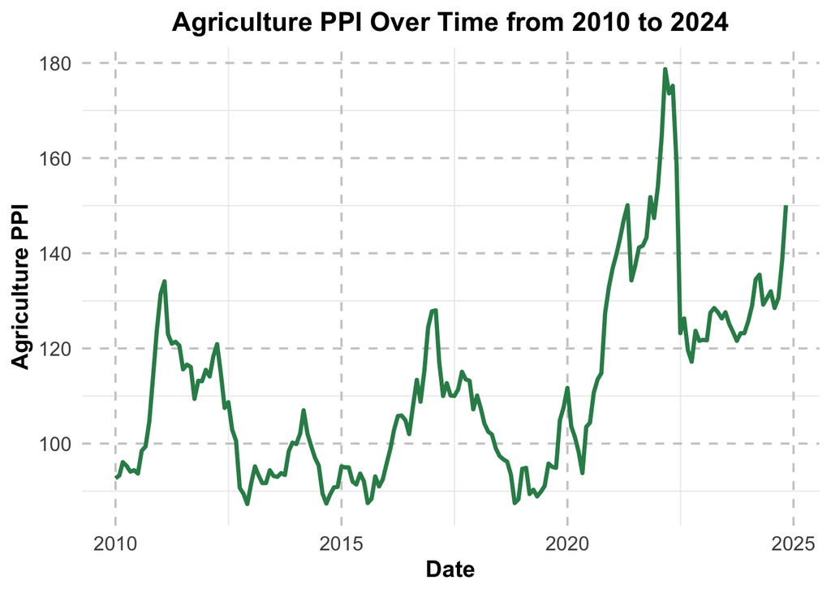

```r
# Plot Agriculture PPI over time
ggplot(data, aes(x = as.Date(date), y = agriculture)) +
  geom_line(color = "#2E8B57", size = 1.2) +
  ggtitle("Agriculture PPI Over Time from 2010 to 2024") +
  xlab("Date") +
  ylab("Agriculture PPI") +
  theme_minimal(base_size = 14) +
  theme(
    plot.title = element_text(face = "bold", size = 16, hjust = 0.5),
    axis.title = element_text(size = 14, face = "bold"),
    axis.text = element_text(size = 12),
    panel.grid.major = element_line(color = "gray80", linetype = "dashed")
  )
```

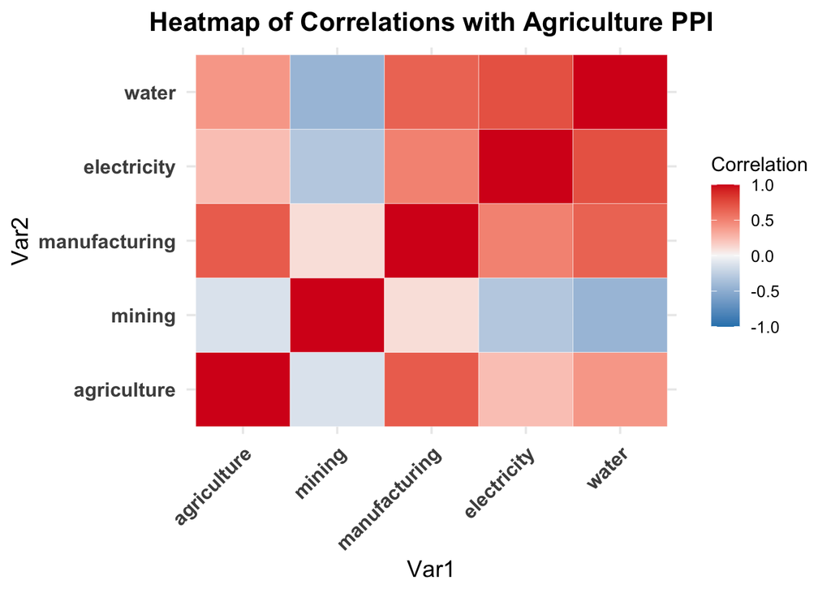

```r
# Plot correlation between Agriculture PPI and Mining PPI
correlation_matrix <- cor(
  data[, c("agriculture", "mining", "manufacturing", "electricity", "water")],
  use = "complete.obs"
)
correlation_data <- melt(correlation_matrix)
ggplot(correlation_data, aes(x = Var1, y = Var2, fill = value)) +
  geom_tile(color = "white") +  # Add white borders for tiles
  scale_fill_gradient2(
    low = "#2b83ba", high = "#d7191c", mid = "#f7f7f7",
    midpoint = 0, limit = c(-1, 1), name = "Correlation"
  ) +  # Improved color scheme
  ggtitle("Heatmap of Correlations with Agriculture PPI") +
  theme_minimal(base_size = 14) +
  theme(
    axis.text.x = element_text(angle = 45, hjust = 1, size = 12, face = "bold"),
    axis.text.y = element_text(size = 12, face = "bold"),
    plot.title = element_text(face = "bold", size = 16, hjust = 0.5),
    legend.title = element_text(size = 12),
    legend.text = element_text(size = 10)
  )
```

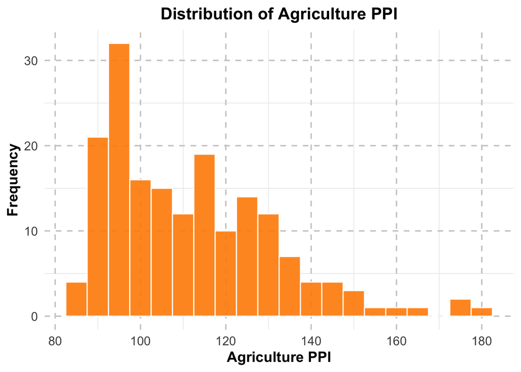

```r
# Plot distribution of Agriculture PPI
ggplot(data, aes(x = agriculture)) +
  geom_histogram(binwidth = 5, fill = "#FF8C00", color = "white", alpha = 0.9) +  # Soft orange with white borders
  ggtitle("Distribution of Agriculture PPI") +
  xlab("Agriculture PPI") +
  ylab("Frequency") +
  theme_minimal(base_size = 14) +
  theme(
    plot.title = element_text(face = "bold", size = 16, hjust = 0.5),  # Centered and bold title
    axis.title = element_text(size = 14, face = "bold"),
    axis.text = element_text(size = 12),
    panel.grid.major = element_line(color = "gray80", linetype = "dashed")
  )
```